# 011.map.troubleshooting.Rmd

Daniele Filiault

5/24/2021

## Introduction

The ColxPat genetic map Diego made is 10x longer than expected. He used the MSTmap online tool. I am going to try using the R/ASMap package, which uses the same algorithms, but allows for more flexibility and troubleshooting.

Will just try Chr1 first.

## 1. Load data

```r
up.gt.file <- "../008.diego.data/genotypes.chr1.txt" ## formatted correctly from Diego
up.dat <- read.table(file=up.gt.file, stringsAsFactors=FALSE)

chr1.dat <- mstmap.data.frame(up.dat, pop.type = "RIL6", dist.fun = "kosambi", objective.fun = "COUNT", p.value = 1e-06, noMap.dist = 5, noMap.size = 0, miss.thresh = 1, mvest.bc = FALSE, as.cross = TRUE, return.imputed = FALSE, trace = TRUE)
```

## 2. Assess and remove missing data

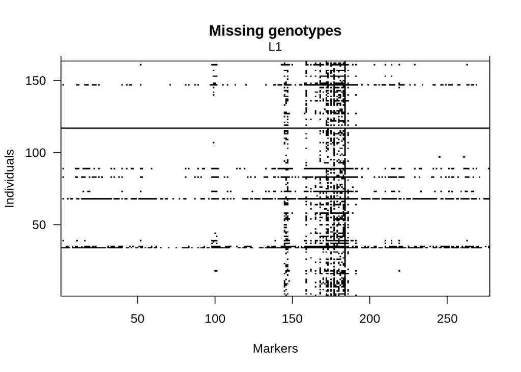

```r
plotMissing(chr1.dat)
```

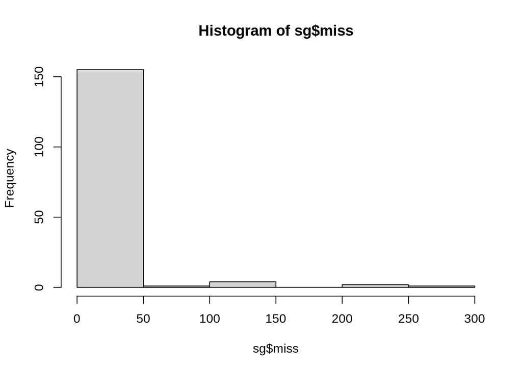

```r
sg <- statGen(chr1.dat, bychr = FALSE, stat.type = "miss")
hist(sg$miss)
```

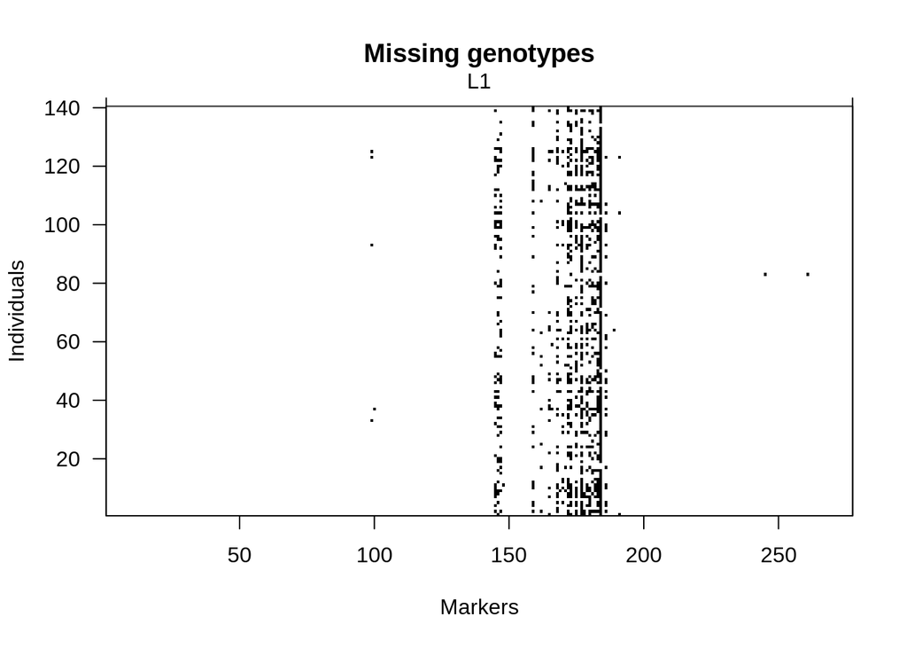

```r
#let's only keep lines with <10% missing genotypes
chr1.dat <- subset(chr1.dat, ind = sg$miss < (ncol(up.dat)*0.1)) #140 individuals
plotMissing(chr1.dat)
```

There are lines and markers with a large amount of missing data. According to the ASMap tutorial (https://cran.r-project.org/web/packages/ASMap/vignettes/asmapvignette.pdf), lines with missing data can lead to overestimations of map distances and should be removed from map calculations. Removed lines with >10% missing data

```r
profileMark(chr1.dat, stat.type = c("seg.dist", "prop", "miss","dxo"), crit.val =
"bonf", layout = c(1, 8), type = "l", cex = 0.5)
```

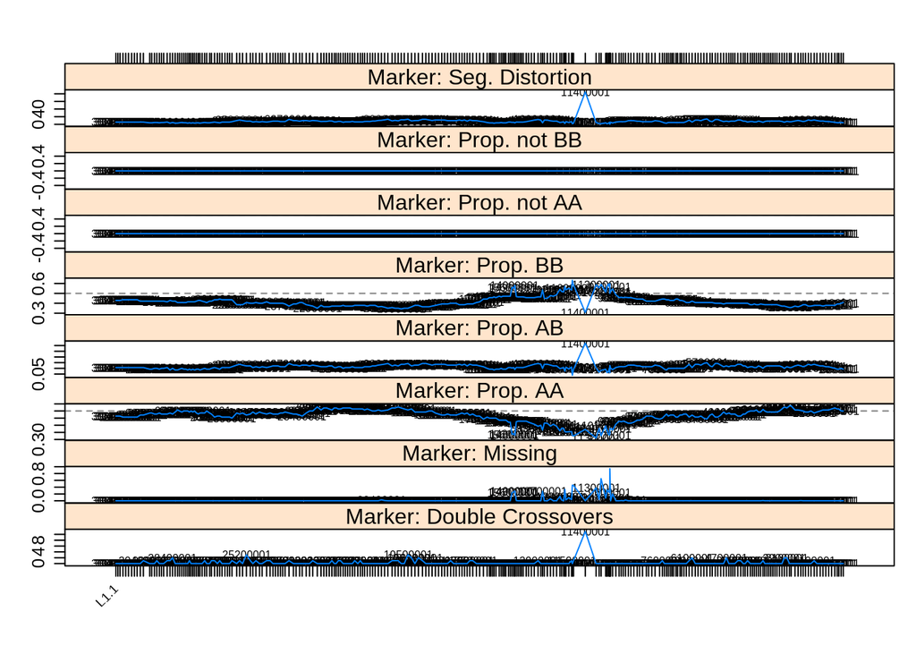

```r
# remove markers with high proportion of missing data
chr1.dat <- pullCross(chr1.dat, type = "missing", pars = list(miss.thresh =
0.02))

# remove markers with extreme segregation distortion
gt <- geno.table(chr1.dat)
gt[-log10(gt$P.value) > 15,] # this cutoff is arbitrary - there is a lot of segregation distortion here and i only want to remove this very badly behaving marker!
```

```
##          chr missing AA AB BB not.BB not.AA      P.value
## 11400001  L1       0 52 45 43      0      0 2.055778e-85
```

```r
todrop <- rownames(gt[-log10(gt$P.value) > 15,])
chr1.dat <- drop.markers(chr1.dat, todrop)
profileMark(chr1.dat, stat.type = c("seg.dist", "prop", "miss","dxo"), crit.val =
"bonf", layout = c(1, 8), type = "l", cex = 0.5)
```

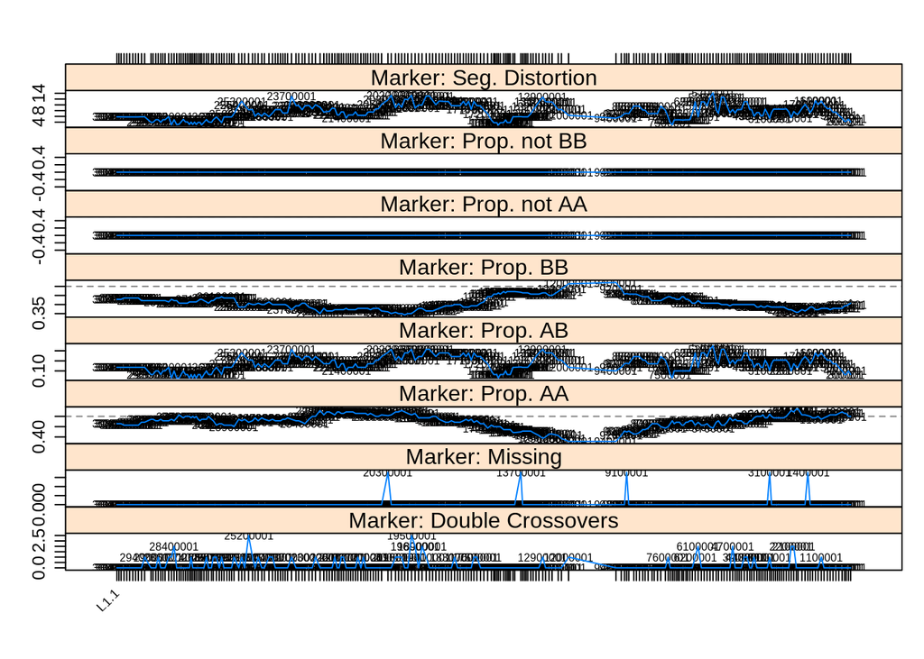

So I see some problematic markers here. Filter for proportion missing, segregation distortion. This takes care of the markers that are also problematic in other areas. The amount of double crossovers is also a bit concerning, but ignore for now.

This is just for chr1 - might be other problems on other chromosomes??

In any case, marker profiles look much better now.